# Univariate Plots Section

### volative.acidity & quality

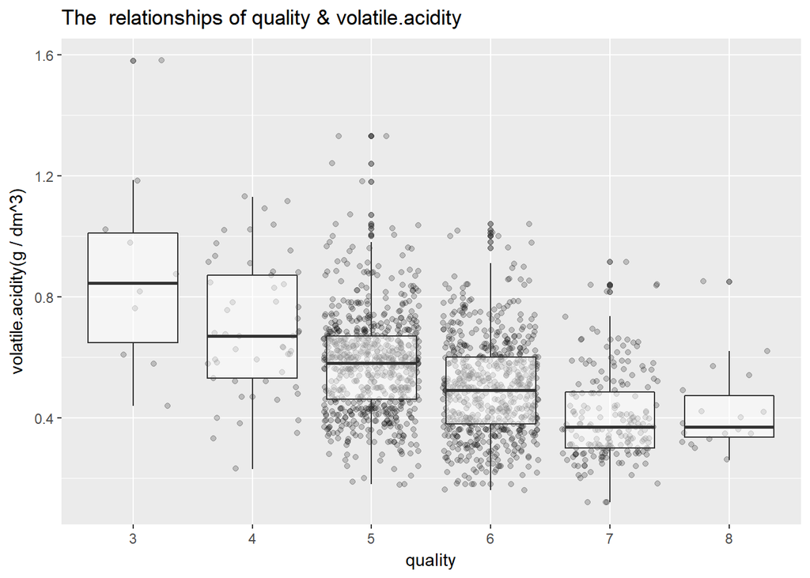

```r
ggplot(aes(x=factor(quality),y=volatile.acidity),data=wq)+
  geom_jitter(alpha=1/5)+
  geom_boxplot(alpha=1/2)+
  xlab("quality") +
  ylab("volatile.acidity(g / dm^3)") +
  ggtitle("The  relationships of quality & volatile.acidity ")
```

```r
by(wq$volatile.acidity,wq$quality,summary)
```

```
## wq$quality: 3
##    Min. 1st Qu.  Median    Mean 3rd Qu.    Max.
##  0.4400  0.6475  0.8450  0.8845  1.0100  1.5800
## --------------------------------------------------------
## wq$quality: 4
##    Min. 1st Qu.  Median    Mean 3rd Qu.    Max.
##   0.230   0.530   0.670   0.694   0.870   1.130
## --------------------------------------------------------
## wq$quality: 5
##    Min. 1st Qu.  Median    Mean 3rd Qu.    Max.
##   0.180   0.460   0.580   0.577   0.670   1.330
## --------------------------------------------------------
## wq$quality: 6
##    Min. 1st Qu.  Median    Mean 3rd Qu.    Max.
##  0.1600  0.3800  0.4900  0.4975  0.6000  1.0400
## --------------------------------------------------------
## wq$quality: 7
##    Min. 1st Qu.  Median    Mean 3rd Qu.    Max.
##  0.1200  0.3000  0.3700  0.4039  0.4850  0.9150
## --------------------------------------------------------
## wq$quality: 8
##    Min. 1st Qu.  Median    Mean 3rd Qu.    Max.
##  0.2600  0.3350  0.3700  0.4233  0.4725  0.8500
```

volatile.acidity和quality相关系数为-0.39，呈负相关。quality得分越高，volatile.acidity也随降低。volatile.acidity指挥发性酸度，葡萄酒中乙酸的含量过高会导致不愉快的醋味

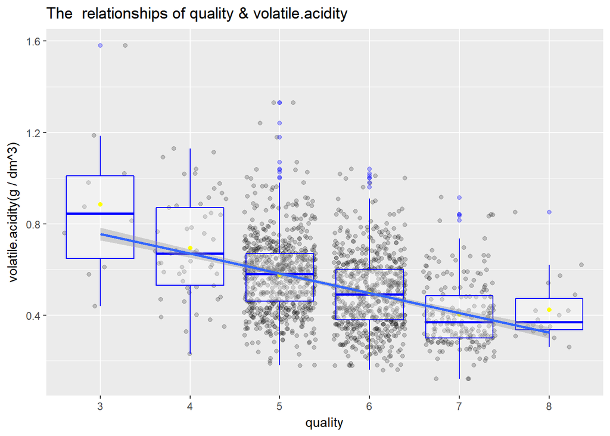

```r
ggplot(wq,aes(factor(quality),volatile.acidity))+
  geom_jitter(alpha=0.2)+
  geom_boxplot(alpha=0.3,color='blue')+
  stat_summary(fun.y ="mean",
               geom="point",
               color="yellow")+
  geom_smooth(method='lm',aes(group=1))+
  xlab("quality") +
  ylab("volatile.acidity(g / dm^3)") +
  ggtitle("The  relationships of quality & volatile.acidity ")
```

一般来说，红酒的质量越好，挥发性酸的含量越低。

### citric.acid & quality

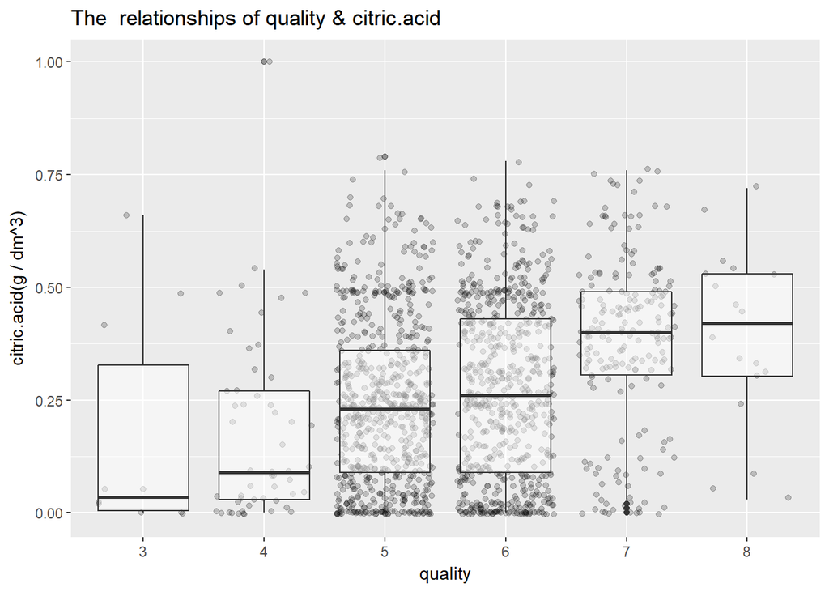

```r
ggplot(aes(x=factor(quality),y=citric.acid),data=wq)+
  geom_jitter(alpha=1/5)+
  geom_boxplot(alpha=1/2)+
  xlab("quality") +
  ylab("citric.acid(g / dm^3)") +
  ggtitle("The  relationships of quality & citric.acid ")
```

```r
by(wq$citric.acid,wq$quality,summary)
```

```
## wq$quality: 3
##    Min. 1st Qu.  Median    Mean 3rd Qu.    Max.
##  0.0000  0.0050  0.0350  0.1710  0.3275  0.6600
## --------------------------------------------------------
## wq$quality: 4
##    Min. 1st Qu.  Median    Mean 3rd Qu.    Max.
##  0.0000  0.0300  0.0900  0.1742  0.2700  1.0000
## --------------------------------------------------------
## wq$quality: 5
##    Min. 1st Qu.  Median    Mean 3rd Qu.    Max.
##  0.0000  0.0900  0.2300  0.2437  0.3600  0.7900
## --------------------------------------------------------
## wq$quality: 6
##    Min. 1st Qu.  Median    Mean 3rd Qu.    Max.
##  0.0000  0.0900  0.2600  0.2738  0.4300  0.7800
## --------------------------------------------------------
## wq$quality: 7
##    Min. 1st Qu.  Median    Mean 3rd Qu.    Max.
##  0.0000  0.3050  0.4000  0.3752  0.4900  0.7600
## --------------------------------------------------------
## wq$quality: 8
##    Min. 1st Qu.  Median    Mean 3rd Qu.    Max.
##  0.0300  0.3025  0.4200  0.3911  0.5300  0.7200
```

citric.acid和quality的相关系数为0.226，为正相关。当quality越高，citric.acid也随之增高。柠檬酸: 少量, 柠檬酸可以增加葡萄酒的 ‘新鲜’ 和风味

### pH & quality

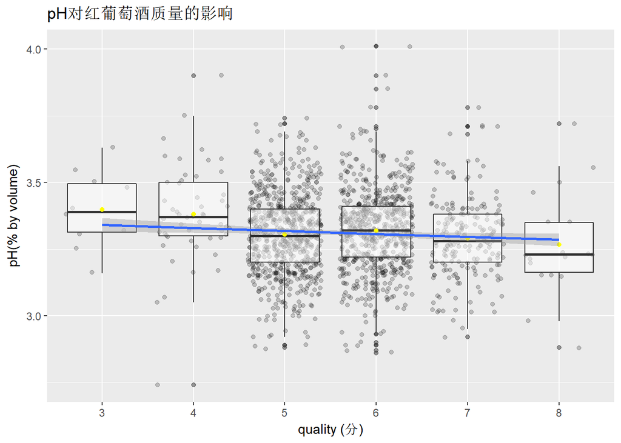

```r
ggplot(aes(x=factor(quality),y=pH),data=wq)+
  geom_jitter(alpha=1/5)+
  geom_boxplot(alpha=1/2)+
  stat_summary(fun.y ="mean",
               geom="point",
               color="yellow")+
  geom_smooth(method='lm',aes(group=1))+
  labs(y = 'pH(% by volume)',x='quality (分)')+
  ggtitle("pH对红葡萄酒质量的影响")
```

```r
by(wq$pH,wq$quality,summary)
```

```
## wq$quality: 3
##    Min. 1st Qu.  Median    Mean 3rd Qu.    Max.
##   3.160   3.312   3.390   3.398   3.495   3.630
## --------------------------------------------------------
## wq$quality: 4
##    Min. 1st Qu.  Median    Mean 3rd Qu.    Max.
##   2.740   3.300   3.370   3.382   3.500   3.900
## --------------------------------------------------------
## wq$quality: 5
##    Min. 1st Qu.  Median    Mean 3rd Qu.    Max.
##   2.880   3.200   3.300   3.305   3.400   3.740
## --------------------------------------------------------
## wq$quality: 6
##    Min. 1st Qu.  Median    Mean 3rd Qu.    Max.
##   2.860   3.220   3.320   3.318   3.410   4.010
## --------------------------------------------------------
## wq$quality: 7
##    Min. 1st Qu.  Median    Mean 3rd Qu.    Max.
##   2.920   3.200   3.280   3.291   3.380   3.780
## --------------------------------------------------------
## wq$quality: 8
##    Min. 1st Qu.  Median    Mean 3rd Qu.    Max.
##   2.880   3.163   3.230   3.267   3.350   3.720
```

pH与红酒质量相关度不高。

### total.sulfur.dioxide & quality

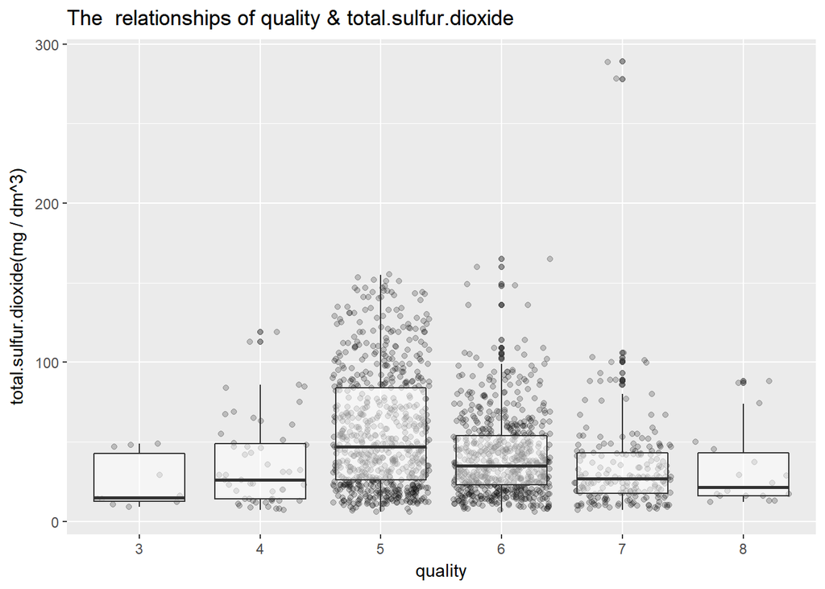

```r
ggplot(aes(x=factor(quality),y=total.sulfur.dioxide),data=wq)+
  geom_jitter(alpha=1/5)+
  geom_boxplot(alpha=1/2)+
  xlab("quality") +
  ylab("total.sulfur.dioxide(mg / dm^3)") +
  ggtitle("The  relationships of quality & total.sulfur.dioxide ")
```

total.sulfur.dioxide与quality的相关度不大。相关系数为-0.18.

### alcohol & density

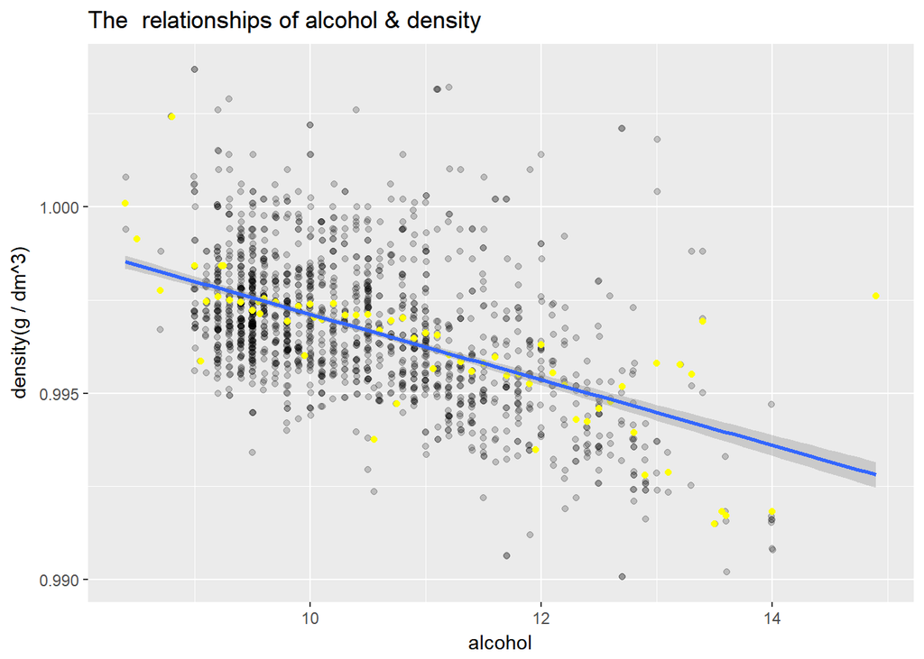

```r
ggplot(aes(x=alcohol,y=density),data=wq)+
  geom_jitter(alpha=1/5)+
  stat_summary(fun.y ="mean",
               geom="point",
               color="yellow")+
  geom_smooth(method='lm',aes(group=1))+
  xlab("alcohol") +
  ylab("density(g / dm^3)") +
  ggtitle("The  relationships of alcohol & density ")
```

由图可知，alchol与density呈负相关。alchol越高，density越低。和我们的常识相符，酒精的密度比水小。

```r
cor.test(wq$alcohol,wq$density,method='pearson')
```

```
##
##  Pearson's product-moment correlation
##
## data:  wq$alcohol and wq$density
## t = -22.838, df = 1597, p-value < 2.2e-16
## alternative hypothesis: true correlation is not equal to 0
## 95 percent confidence interval:
##  -0.5322547 -0.4583061
## sample estimates:
##        cor
## -0.4961798
```

alchol与density呈负相关,中等相关约-0.496.

# Bivariate Analysis

### Talk about some of the relationships you observed in this part of the investigation. How did the feature(s) of interest vary with other features in the dataset?

alcohol,sulohates,citric.acid,volatile.acidity,total.sulfur.dioxide与质量quality的相关性比其他变量稍强一些。可以在多变量分析中进一步观察。

### Did you observe any interesting relationships between the other features (not the main feature(s) of interest)?

pH与红酒质量的相关度不高。 alchol与density呈负相关,中等相关约-0.496.

### What was the strongest relationship you found?

与质量关系相关度最强的是alcohol(47.6%). 其次有是： sulphates：25.1% citric.acid:22.6% volatile.acidity:-39.0% total.sulfur.dioxide:-18.5%

# Multivariate Plots Section

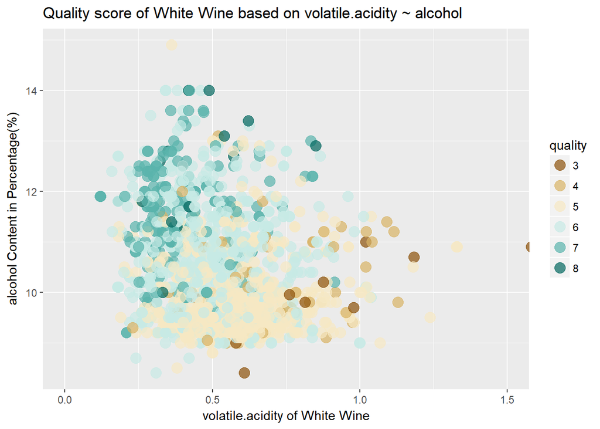

```r
wq$quality <- factor(wq$quality, order = TRUE, levels = c(3,4,5,6,7,8,9))

ggplot(data = wq, aes(x =volatile.acidity, y = alcohol, color = quality)) +
  geom_point(alpha = 0.7, position = position_jitter(h = 0), size = 4) +
  scale_color_brewer(type = 'div') +
  coord_cartesian(xlim = c(0,1.5)) +
  xlab("volatile.acidity of White Wine") +
  ylab("alcohol Content in Percentage(%)") +
  ggtitle("Quality score of White Wine based on volatile.acidity ~ alcohol")
```

一般来说，volatile.acidity较低的，且alcohol较高，红酒质量较好。 反正，则红酒质量较低。

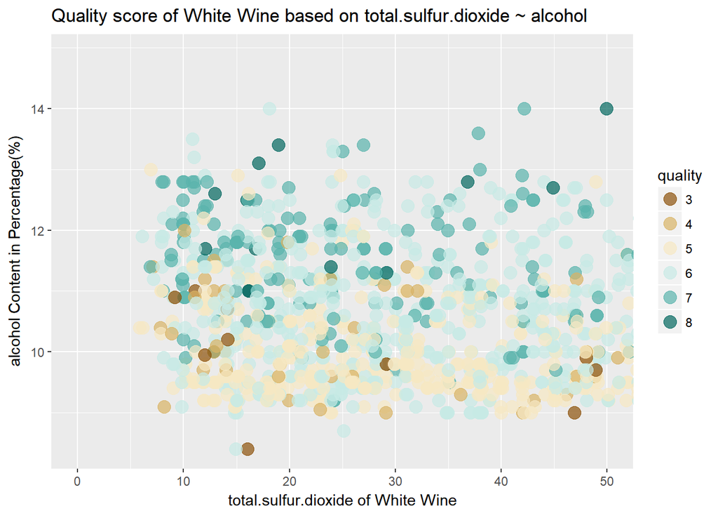

```r
wq$quality <- factor(wq$quality, order = TRUE, levels = c(3,4,5,6,7,8,9))

ggplot(data = wq, aes(x = total.sulfur.dioxide, y = alcohol, color = quality)) +
  geom_point(alpha = 0.7, position = position_jitter(h = 0), size = 4) +
  scale_color_brewer(type = 'div') +
  coord_cartesian(xlim = c(0,50)) +
  xlab("total.sulfur.dioxide of White Wine") +
  ylab("alcohol Content in Percentage(%)") +
  ggtitle("Quality score of White Wine based on total.sulfur.dioxide ~ alcohol")
```

一般来说，alcohol较高的，红酒质量得分较高。total.sulfur.dioxide与红酒质量的相关度不大。

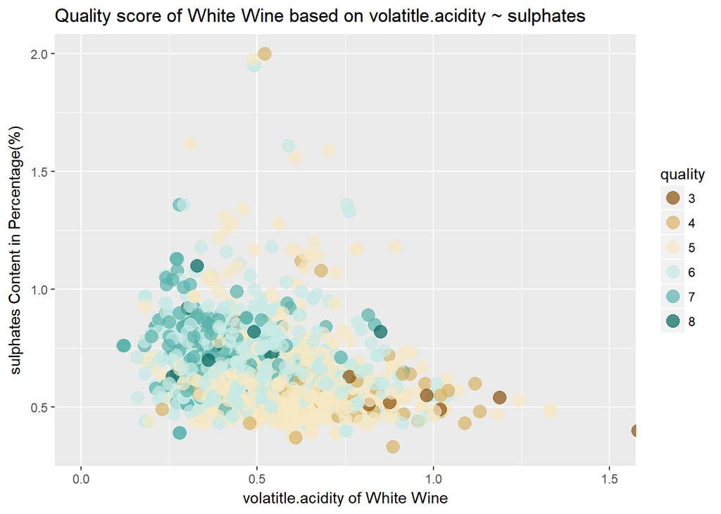

```r
wq$quality <- factor(wq$quality, order = TRUE, levels = c(3,4,5,6,7,8,9))

ggplot(data = wq, aes(x =volatile.acidity, y =sulphates, color = quality)) +
  geom_point(alpha = 0.7, position = position_jitter(h = 0), size = 4) +
  scale_color_brewer(type = 'div') +
  coord_cartesian(xlim = c(0, 1.5)) +
  xlab("volatitle.acidity of White Wine") +
  ylab("sulphates Content in Percentage(%)") +
  ggtitle("Quality score of White Wine based on volatitle.acidity ~ sulphates")
```

有图得：sulphates较高，且volatitle.acidity较低，红酒的质量得分较高。 sulphates较低，volatitle.acidity较高，红酒的质量得分较低。

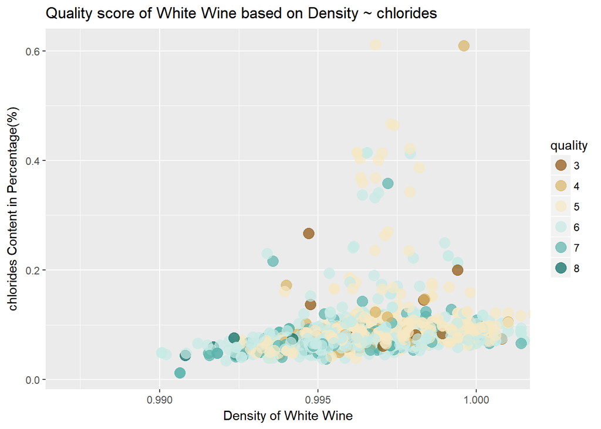

```r
wq$quality <- factor(wq$quality, order = TRUE, levels = c(3,4,5,6,7,8,9))

ggplot(data = wq, aes(x = density, y = chlorides, color = quality)) +
  geom_point(alpha = 0.7, position = position_jitter(h = 0), size = 4) +
  scale_color_brewer(type = 'div') +
  coord_cartesian(xlim = c(0.9871, 1.001)) +
  xlab("Density of White Wine") +
  ylab("chlorides Content in Percentage(%)") +
  ggtitle("Quality score of White Wine based on Density ~ chlorides")
```

由图得：一般来说，density较低，chlorides较低，能得到质量好的葡萄红酒。density较高，chlorides较高，葡萄红酒的质量较低。

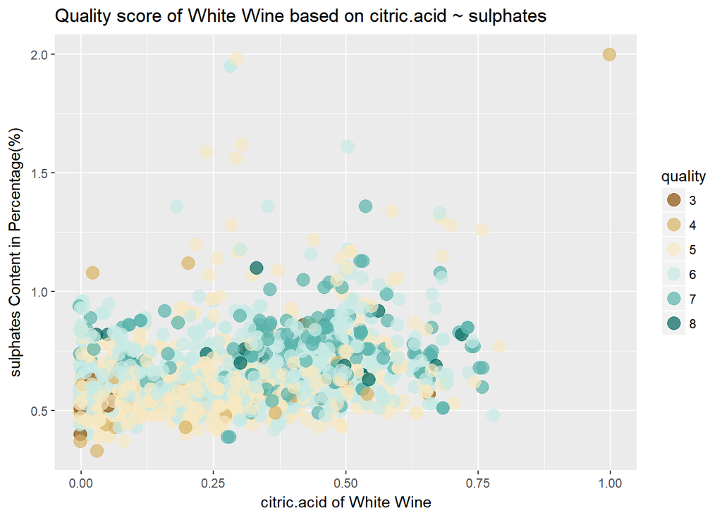

```r
wq$quality <- factor(wq$quality, order = TRUE, levels = c(3,4,5,6,7,8,9))

ggplot(data = wq, aes(x = citric.acid, y = sulphates, color = quality)) +
  geom_point(alpha = 0.7, position = position_jitter(h = 0), size = 4) +
  scale_color_brewer(type = 'div') +
  coord_cartesian(xlim = c(0,1)) +
  xlab("citric.acid of White Wine") +
  ylab("sulphates Content in Percentage(%)") +
  ggtitle("Quality score of White Wine based on citric.acid ~ sulphates")
```

一般来说，citric.acid较高，红酒质量较好。sulphates对其影响一般。